# Forecasting Projects: Queensland Takeaway Food Services Turnover

Author

Ting-Ting, Wu - 35717343

## Project 1: Benchmark Forecasting and Transformation (IA2)

### Question 1

*What is your data about (no more than 50 words)? Produce appropriate plots in order to become familiar with your data. Make sure you label your axes and plots appropriately. Comment on these. What do you see? (no more than 50 words per plot). (14 marks)*

#### What is your data about?

This monthly series records Queensland takeaway food services turnover in $ millions from April 1982 to June 2023. It measures original monthly retail turnover and is used to examine long-run growth, recurring seasonal patterns, changing variation, and unusual disruptions.

#### Time plot

Figure 1 shows a strong upward trend from about $25 million in 1982 to above $400 million by 2023. Seasonal swings become larger as the level rises, so the variation is not constant. The COVID-period dip around April 2020 is an unusual downward movement.

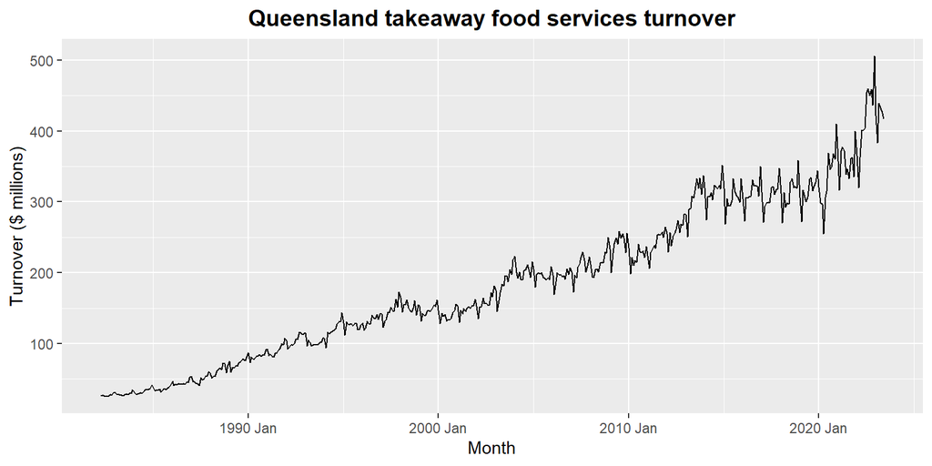

Figure 1: Monthly Queensland takeaway food services turnover from April 1982 to June 2023.

```r
my_series %>%
  autoplot(y) +
  labs(
    title = "Queensland takeaway food services turnover",
    x = "Month",
    y = "Turnover ($ millions)"
  ) +
  theme(plot.title = element_text(hjust = 0.5, face = "bold", size = 14))
```

#### Season plot

The season plot in Figure 2 shows clear monthly seasonality. Turnover is usually lowest around February and highest in December, with a repeated within-year pattern. The later years sit higher than earlier years, and the 2020 line shows a noticeable interruption during the COVID period.

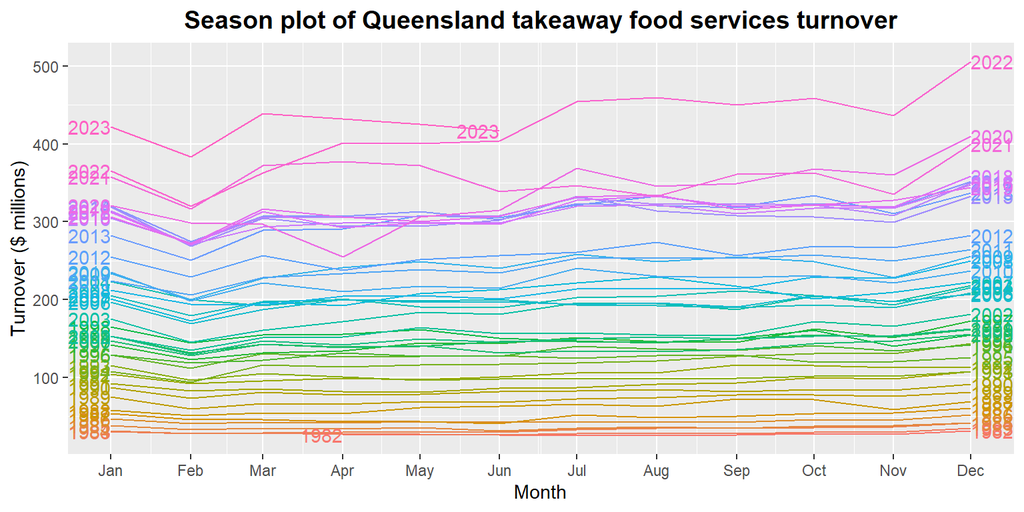

Figure 2: Season plot of Queensland takeaway food services turnover.

```r
my_series %>%
  gg_season(y, labels = "both") +
  labs(
    title = "Season plot of Queensland takeaway food services turnover",
    x = "Month",
    y = "Turnover ($ millions)"
  ) +
  theme(plot.title = element_text(hjust = 0.5, face = "bold", size = 14))
```

#### Subseries plot

Figure 3 confirms the monthly pattern. December has the highest average turnover, while February is generally lower. Most monthly subseries rise over time, and the vertical spread grows in later years, showing both trend and increasing variation within each month.

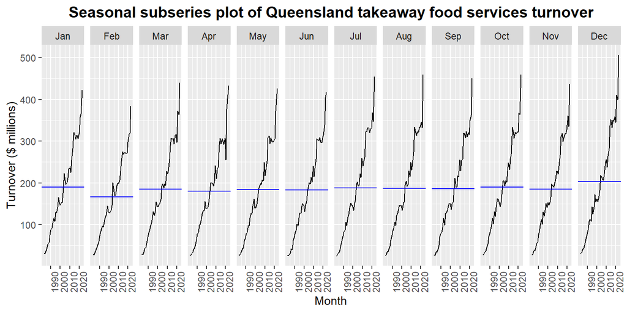

Figure 3: Seasonal subseries plot of Queensland takeaway food services turnover.

```r
my_series %>%
  gg_subseries(y) +
  labs(
    title = "Seasonal subseries plot of Queensland takeaway food services turnover",
    x = "Month",
    y = "Turnover ($ millions)"
  ) +
  theme(plot.title = element_text(hjust = 0.5, face = "bold", size = 14))
```

### Question 2

*Would transforming your data be useful (no more than 50 words)? Compare different transformations graphically. Choose the best transformation if you think a transformation is needed. Justify your choice (no more than 50 words). (5 marks)*

Transformation would be useful because the time plot shows larger seasonal swings and residual variation when turnover is higher. A variance-stabilising transformation can reduce this level-dependent spread, making benchmark forecasts and later models easier to interpret.

```r
lambda_tbl <- my_series %>%
  features(y, guerrero)

lambda_tbl %>%
  mutate(lambda_guerrero = round(lambda_guerrero, 4)) %>%
  rename(`Guerrero lambda` = lambda_guerrero) %>%
  kable(caption = "Estimated transformation parameter from Guerrero's method")
```

Table 1: Estimated transformation parameter from Guerrero’s method

| Guerrero lambda |
| --- |
| 0.0595 |

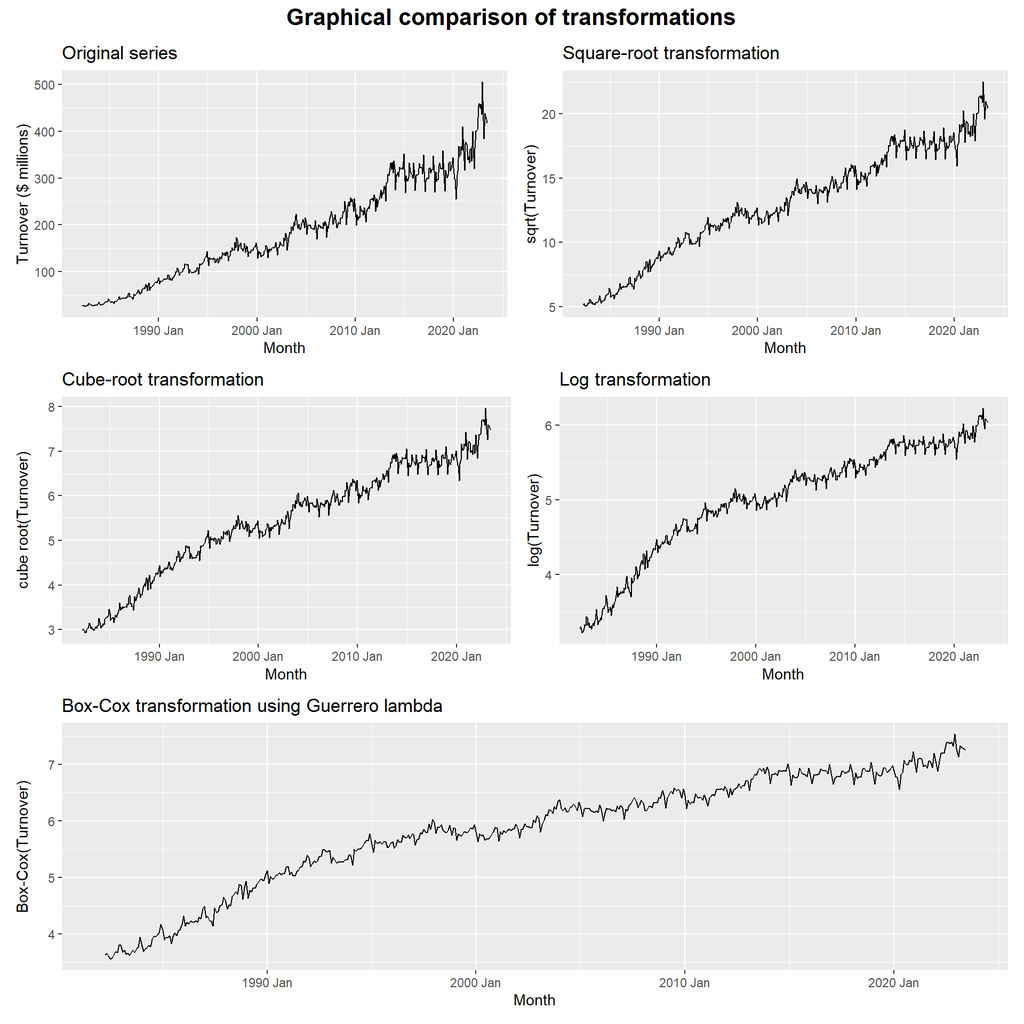

Figure 4: Comparison of original, root, log and Box-Cox transformed series.

```r
p1 <- my_series %>%
  autoplot(y) +
  labs(
    title = "Original series",
    x = "Month",
    y = "Turnover ($ millions)"
  )

p2 <- my_series %>%
  autoplot(sqrt(y)) +
  labs(
    title = "Square-root transformation",
    x = "Month",
    y = "sqrt(Turnover)"
  )

p3 <- my_series %>%
  autoplot(y^(1/3)) +
  labs(
    title = "Cube-root transformation",
    x = "Month",
    y = "cube root(Turnover)"
  )

p4 <- my_series %>%
  autoplot(log(y)) +
  labs(
    title = "Log transformation",
    x = "Month",
    y = "log(Turnover)"
  )

p5 <- my_series %>%
  autoplot(box_cox(y, lambda_tbl$lambda_guerrero)) +
  labs(
    title = "Box-Cox transformation using Guerrero lambda",
    x = "Month",
    y = "Box-Cox(Turnover)"
  )

(p1 | p2) / (p3 | p4) / p5 +
  plot_annotation(
    title = "Graphical comparison of transformations",
    theme = theme(
      plot.title = element_text(hjust = 0.5, face = "bold", size = 16)
    )
  )
```

Guerrero’s method gives $\lambda \approx 0.0595$, close to 0, so the log transformation is a simple approximation to the Box-Cox recommendation. Compared with square-root and cube-root transformations, `log(y)` makes the spread most stable across the sample, so I use `log(y)` for modelling.

### Question 3

*Split your data into training and test sets. Leave the last two years’ worth of observations as the test set. Plot these on the same graph to make sure you have done this properly. (3 marks)*

```r
train <- my_series %>%
  slice(1:(n() - 24))

test <- my_series %>%
  slice((n() - 23):n())

tibble(
  Set = c("Training", "Test"),
  Start = c(min(train$Month), min(test$Month)),
  End = c(max(train$Month), max(test$Month)),
  Observations = c(nrow(train), nrow(test))
) %>%
  kable(caption = "Summary of the training and test sets")
```

Summary of the training and test sets

| Set | Start | End | Observations |
| --- | --- | --- | --- |
| Training | 1982 Apr | 2021 Jun | 471 |
| Test | 2021 Jul | 2023 Jun | 24 |

Figure 5 uses different colours to clearly identify the training series and the test series. The test set is the final 24 monthly observations, from July 2021 to June 2023.

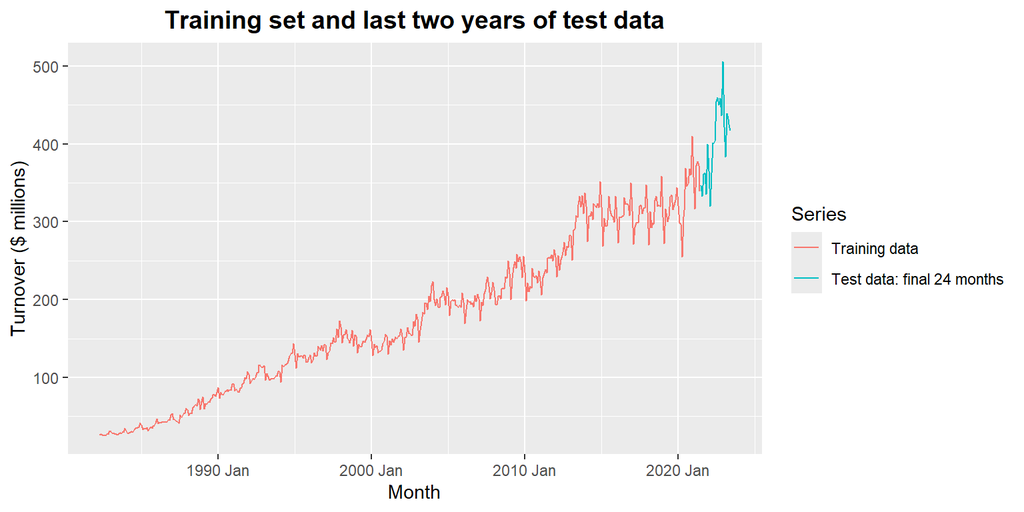

Figure 5: Training and test split for Queensland takeaway food services turnover.

```r
split_series <- bind_rows(
  train %>% mutate(Set = "Training data"),
  test %>% mutate(Set = "Test data: final 24 months")
) %>%
  mutate(Set = factor(Set, levels = c("Training data", "Test data: final 24 months")))

split_series %>%
  ggplot(aes(x = Month, y = y, colour = Set)) +
  geom_line() +
  labs(
    title = "Training set and last two years of test data",
    x = "Month",
    y = "Turnover ($ millions)",
    colour = "Series"
  ) +
  theme(plot.title = element_text(hjust = 0.5, face = "bold", size = 14))
```

### Question 4

*Apply the two most appropriate benchmark methods on the training set. Generate forecasts for the test set and plot them on the same graph. Compare their forecasting performance on the test set. Which method would you choose as the appropriate benchmark? Justify your answer (no more 100 words). (Hint: it will be useful to tabulate your results.) (12 marks)*

I use seasonal naïve and drift as the two benchmarks. Seasonal naïve repeats last year’s monthly pattern but cannot capture continued growth. Drift captures the long-run upward movement but is not seasonal. Table 2 shows drift has lower RMSE, MAE and MAPE, and Figure 6 shows it follows the higher test-period level more closely. I choose drift. MASE/RMSSE are NaN because the scaling denominators are not available when accuracy is calculated only against this transformed holdout set, so I compare RMSE, MAE and MAPE.

```r
fit <- train %>%
  model(
    snaive = SNAIVE(log(y)),
    drift = RW(log(y) ~ drift())
  )

fc <- fit %>%
  forecast(h = "2 years")
```

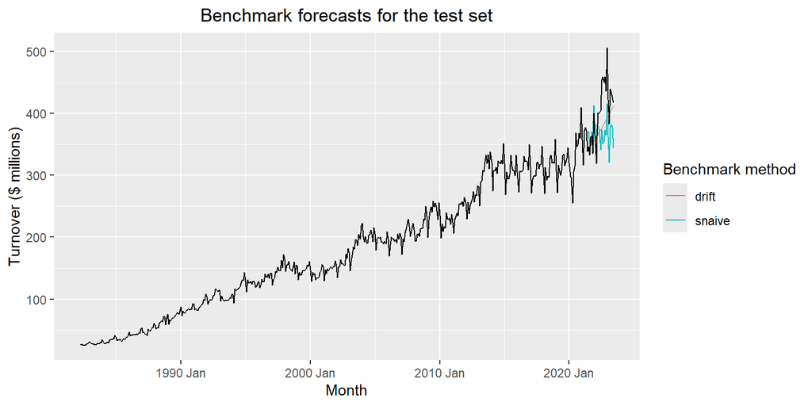

Figure 6: Benchmark forecasts for the final two-year test set.

```r
fc %>%
  autoplot(my_series, level = NULL) +
  labs(
    title = "Benchmark forecasts for the test set",
    x = "Month",
    y = "Turnover ($ millions)",
    colour = "Benchmark method"
  ) +
  theme(plot.title = element_text(hjust = 0.5))
```

```r
acc_tbl <- fc %>%
  accuracy(test) %>%
  select(.model, .type, ME, RMSE, MAE, MPE, MAPE, MASE, RMSSE, ACF1)

acc_tbl %>%
  mutate(across(where(is.numeric), round, 3)) %>%
  kable(caption = "Forecast accuracy on the test set")
```

Table 2: Forecast accuracy on the final two-year test set.

Forecast accuracy on the test set

| .model | .type | ME | RMSE | MAE | MPE | MAPE | MASE | RMSSE | ACF1 |
| --- | --- | --- | --- | --- | --- | --- | --- | --- | --- |
| drift | Test | 27.628 | 44.929 | 34.924 | 6.016 | 8.193 | NaN | NaN | 0.450 |
| snaive | Test | 38.147 | 56.546 | 46.380 | 8.508 | 10.859 | NaN | NaN | 0.839 |

### Question 5

*For the best method, do a residual analysis. Comment on these. What did your forecasting method miss? (no more than 150 words) (8 marks)*

Figure 7 shows residuals roughly centred near zero, but the variance is not completely constant and the histogram has a slightly heavier left tail. The ACF shows strong seasonal spikes at lags 12 and 24, with smaller negative spikes around 6 and 18 months. The Ljung-Box test in Table 3 uses lag 24 and dof 1. Its null is $H_0: \rho_1 = \cdots = \rho_{24} = 0$, meaning the first 24 residual autocorrelations are jointly insignificant. Since the p-value is below 0.05, I reject $H_0$. Therefore, the drift benchmark misses important seasonal autocorrelation. It captures long-run growth but not yearly seasonal movements.

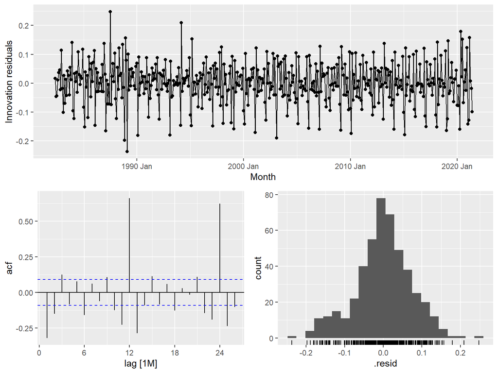

Figure 7: Residual diagnostics for the drift benchmark model.

```r
drift_fit <- train %>%
  model(drift = RW(log(y) ~ drift()))

drift_fit %>%
  gg_tsresiduals()
```

```r
drift_fit %>%
  augment() %>%
  features(.innov, ljung_box, lag = 24, dof = 1) %>%
  kable(digits = 3)
```

Table 3: Ljung-Box test for residual autocorrelation in the drift benchmark model.

| .model | lb_stat | lb_pvalue |
| --- | --- | --- |
| drift | 629.715 | 0 |

### Question 6

*Generate point forecasts for the next 2 years (future) from the benchmark method you considered best and plot them. Comment on these.(4 marks)*

Figure 8 shows forecasts increasing steadily on the original scale, but they are smooth because drift extrapolates average log growth. The intervals widen with horizon, showing greater uncertainty. Since the model is not seasonal, future peaks and troughs are not captured.

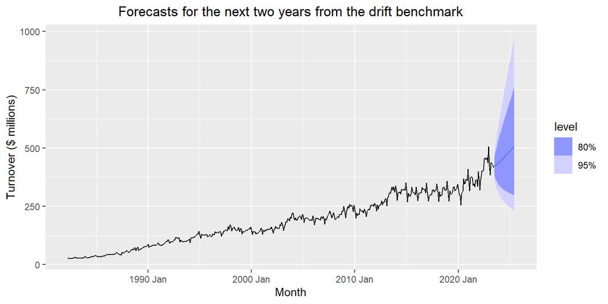

Figure 8: Two-year future forecasts from the drift benchmark model.

```r
final_fit <- my_series %>%
  model(drift = RW(log(y) ~ drift()))

future_fc <- final_fit %>%
  forecast(h = "2 years")

future_fc %>%
  autoplot(my_series, level = c(80, 95)) +
  labs(
    title = "Forecasts for the next two years from the drift benchmark",
    x = "Month",
    y = "Turnover ($ millions)"
  ) +
  theme(plot.title = element_text(hjust = 0.5))
```

## Project 2: ETS Modelling and Forecast Evaluation (IA3)

For the tasks that follow you will be modelling the **original data without any transformations** performed (even if you previously deemed it necessary).

### Question 1

*Plot your time series. By observing the plot and describing its components select an ETS model you think is appropriate for forecasting. Make sure you justify your choice (no more than 150 words). (8 marks)*

Figure 9 shows a clear upward trend and strong monthly seasonality. The seasonal fluctuations become larger as the level of the series increases, which suggests multiplicative seasonality. The random variation also appears larger at higher turnover levels, so multiplicative errors are appropriate. The trend is persistent and approximately linear over most of the sample, so I use an additive trend rather than a damped trend for my initial model. Therefore, ETS(M,A,M) is suitable because it combines multiplicative errors, additive trend and multiplicative seasonality.

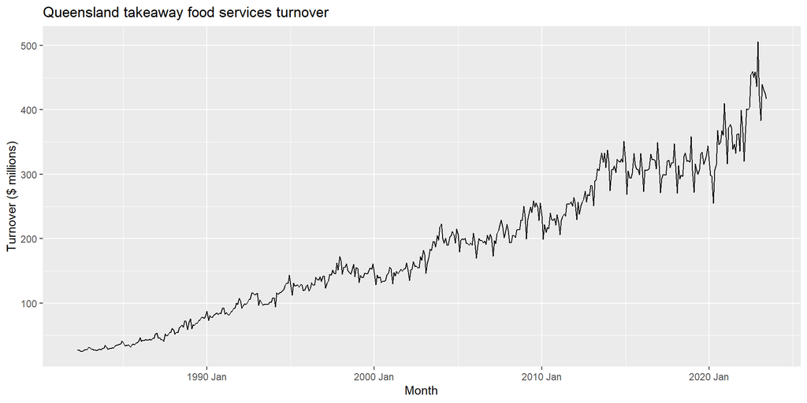

Figure 9: Queensland takeaway food services turnover over time.

```r
my_series %>%
  autoplot(y) +
  labs(
    title = "Queensland takeaway food services turnover",
    x = "Month",
    y = "Turnover ($ millions)"
  )
```

### Question 2

*Estimate the ETS model you described in Question 1 and show the estimated model output. Describe and comment on the estimated parameters and components. Include any plots you see necessary (no more than 150 words). (14 marks)*

The estimated model output from report(fit) supports the choice of ETS(M,A,M) in Question 1. The level smoothing parameter is fairly large, with $\alpha = 0.6795$, so the level is updated quite quickly when new observations come in. The trend smoothing parameter is almost zero, with $\beta = 0.0002$, which suggests that the trend is very stable over time. The seasonal smoothing parameter is moderate, with $\gamma = 0.1157$, meaning that the seasonal pattern can still change over time, but not dramatically. As shown in Figure 10, the estimated level exhibits a clear upward trend, while the seasonal component is fairly stable with some variation over time. The initial level, positive initial trend, and seasonal indices close to 1 are also consistent with the overall upward movement and multiplicative seasonality in the series. Overall, the estimated parameters and components look reasonable for this data.

```r
fit <- my_series %>%
  model(hw_mul = ETS(y ~ error("M") + trend("A") + season("M")))

report(fit)
```

```
Series: y
Model: ETS(M,A,M)
  Smoothing parameters:
    alpha = 0.6795129
    beta  = 0.0001772132
    gamma = 0.1157135

  Initial states:
     l[0]      b[0]     s[0]    s[-1]    s[-2]    s[-3]     s[-4]    s[-5]
 27.34888 0.4954302 1.017293 0.960553 1.067996 1.064265 0.9669186 1.001924
     s[-6]     s[-7]    s[-8]     s[-9]   s[-10]    s[-11]
 0.9866014 0.9926638 1.003601 0.9621618 1.002828 0.9731934

  sigma^2:  0.002

     AIC     AICc      BIC
4954.254 4955.537 5025.732
```

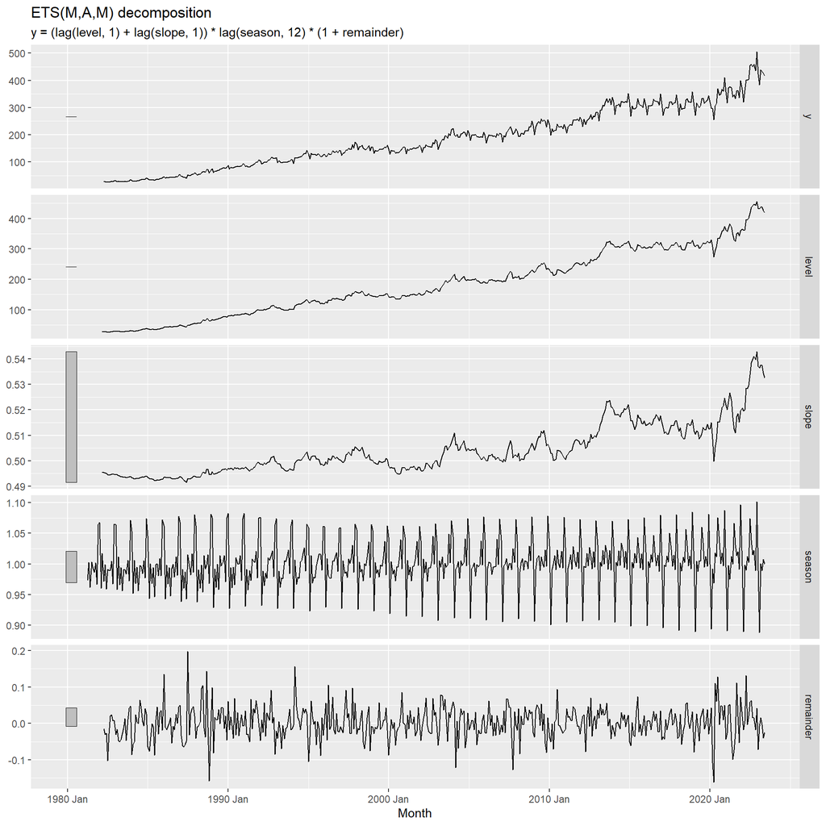

Figure 10: Estimated components from the ETS(M,A,M) model.

```r
fit %>%
  components() %>%
  autoplot()
```

### Question 3

*Plot the residuals from the model and comment on these (no more than 50 words). Perform some diagnostic checks and comment on whether you are satisfied with the fit of the model (no more than 50 words). (Make sure you state all relevant information for any hypothesis test you perform such as the null hypothesis, the degrees of freedom, the decision, etc.). (10 marks)*

Figure 11 gives three diagnostics: residual time plot, histogram, and ACF. The residuals fluctuate around zero with fairly stable spread. The histogram is roughly symmetric but has a few outliers. The ACF has no dominant seasonal spike, although some small lag correlations remain.

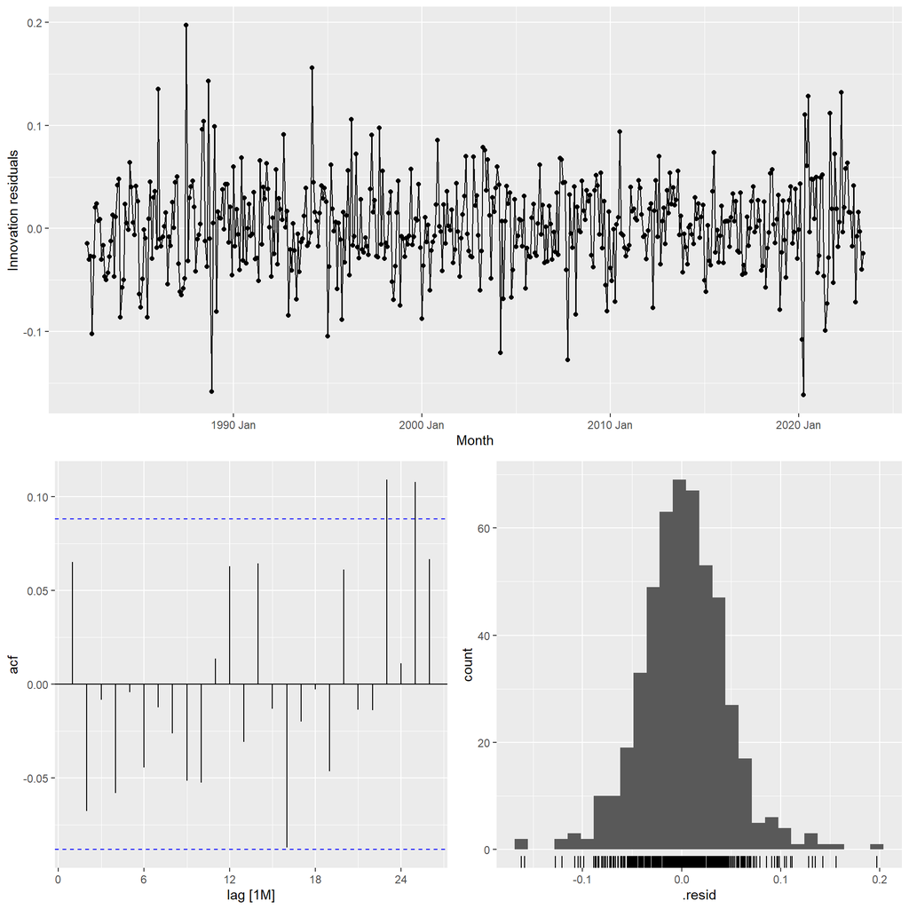

Figure 11: Residual diagnostics for the ETS(M,A,M) model.

```r
fit %>%
  gg_tsresiduals()
```

The Ljung-Box test in Table 4 uses lag 24 and dof 0, so the reference distribution has 24 degrees of freedom. $H_0: \rho_1 = \cdots = \rho_{24} = 0$ jointly. At the 5% level, p = 0.235 > 0.05, so I fail to reject $H_0$. The fit is acceptable.

```r
fit %>%
  augment() %>%
  features(.innov, ljung_box, lag = 24, dof = 0) %>%
  kable(digits = 3)
```

Table 4: Ljung-Box test results for the residuals from the ETS(M,A,M) model.

| .model | lb_stat | lb_pvalue |
| --- | --- | --- |
| hw_mul | 28.605 | 0.235 |

### Question 4

*Let R select an ETS model. What model has been chosen and how has this model been chosen? (No more than 100 words). (6 marks)*

R selected ETS(M,Ad,M), a damped Holt-Winters multiplicative model with multiplicative errors, additive damped trend and multiplicative seasonality. `ETS()` searches across admissible ETS model combinations, excludes unstable models by default, and selects the model with the lowest AICc. Therefore, R chose the stable ETS model that best balances goodness of fit and model complexity.

```r
auto_fit <- my_series %>%
  model(auto_ets = ETS(y))

report(auto_fit)
```

```
Series: y
Model: ETS(M,Ad,M)
  Smoothing parameters:
    alpha = 0.7303359
    beta  = 0.01085401
    gamma = 0.000104766
    phi   = 0.9751912

  Initial states:
     l[0]      b[0]      s[0]     s[-1]    s[-2]    s[-3]     s[-4]    s[-5]
 26.15138 0.2357927 0.9837864 0.9014131 1.039178 1.085545 0.9948487 1.029909
    s[-6]    s[-7]    s[-8]     s[-9]    s[-10]    s[-11]
 1.004992 1.009785 1.019109 0.9727443 0.9876115 0.9710769

  sigma^2:  0.002

     AIC     AICc      BIC
4950.875 4952.311 5026.557
```

### Question 5

*Comment on how the model chosen by R is different to the model you have specified (no more than 50 words). Which of the two models would you choose and why? (no more than 50 words). (Hint: think about model selection here but also check your residuals).*

*If the models are identical specify a plausible alternative. Give a brief justification for your choice (no more than 100 words). (Hint: also check the residuals from this model). (12 marks)*

**How is R’s model different?**

R selected ETS(M,Ad,M), while my specified model was ETS(M,A,M). The automatic model adds a damping parameter, so its trend gradually flattens in longer forecasts. Both models use multiplicative errors and multiplicative seasonality.

**Which model would I choose and why?**

```r
compare_tbl <- bind_rows(
  fit %>%
    glance() %>%
    mutate(model = "Specified: ETS(M,A,M)"),
  auto_fit %>%
    glance() %>%
    mutate(model = "R selected: ETS(M,Ad,M)")) %>%
  select(model, AICc, AIC, BIC)

compare_tbl %>%
  kable(digits = 3)
```

Table 5: Comparison of the specified model and R’s automatically selected ETS model.

| model | AICc | AIC | BIC |
| --- | --- | --- | --- |
| Specified: ETS(M,A,M) | 4955.537 | 4954.254 | 5025.732 |
| R selected: ETS(M,Ad,M) | 4952.311 | 4950.875 | 5026.557 |

```r
parameter_tbl <- bind_rows(
  fit %>% tidy() %>% mutate(model = "Specified: ETS(M,A,M)"),
  auto_fit %>% tidy() %>% mutate(model = "R selected: ETS(M,Ad,M)")
) %>%
  select(model, term, estimate)

parameter_tbl %>%
  kable(digits = 4)
```

Table 6: Estimated parameter comparison for the specified and automatically selected ETS models.

| model | term | estimate |
| --- | --- | --- |
| Specified: ETS(M,A,M) | alpha | 0.6795 |
| Specified: ETS(M,A,M) | beta | 0.0002 |
| Specified: ETS(M,A,M) | gamma | 0.1157 |
| Specified: ETS(M,A,M) | l[0] | 27.3489 |
| Specified: ETS(M,A,M) | b[0] | 0.4954 |
| Specified: ETS(M,A,M) | s[0] | 1.0173 |
| Specified: ETS(M,A,M) | s[-1] | 0.9606 |
| Specified: ETS(M,A,M) | s[-2] | 1.0680 |
| Specified: ETS(M,A,M) | s[-3] | 1.0643 |
| Specified: ETS(M,A,M) | s[-4] | 0.9669 |
| Specified: ETS(M,A,M) | s[-5] | 1.0019 |
| Specified: ETS(M,A,M) | s[-6] | 0.9866 |
| Specified: ETS(M,A,M) | s[-7] | 0.9927 |
| Specified: ETS(M,A,M) | s[-8] | 1.0036 |
| Specified: ETS(M,A,M) | s[-9] | 0.9622 |
| Specified: ETS(M,A,M) | s[-10] | 1.0028 |
| Specified: ETS(M,A,M) | s[-11] | 0.9732 |
| R selected: ETS(M,Ad,M) | alpha | 0.7303 |
| R selected: ETS(M,Ad,M) | beta | 0.0109 |
| R selected: ETS(M,Ad,M) | gamma | 0.0001 |
| R selected: ETS(M,Ad,M) | phi | 0.9752 |
| R selected: ETS(M,Ad,M) | l[0] | 26.1514 |
| R selected: ETS(M,Ad,M) | b[0] | 0.2358 |
| R selected: ETS(M,Ad,M) | s[0] | 0.9838 |
| R selected: ETS(M,Ad,M) | s[-1] | 0.9014 |
| R selected: ETS(M,Ad,M) | s[-2] | 1.0392 |
| R selected: ETS(M,Ad,M) | s[-3] | 1.0855 |
| R selected: ETS(M,Ad,M) | s[-4] | 0.9948 |
| R selected: ETS(M,Ad,M) | s[-5] | 1.0299 |
| R selected: ETS(M,Ad,M) | s[-6] | 1.0050 |
| R selected: ETS(M,Ad,M) | s[-7] | 1.0098 |
| R selected: ETS(M,Ad,M) | s[-8] | 1.0191 |
| R selected: ETS(M,Ad,M) | s[-9] | 0.9727 |
| R selected: ETS(M,Ad,M) | s[-10] | 0.9876 |
| R selected: ETS(M,Ad,M) | s[-11] | 0.9711 |

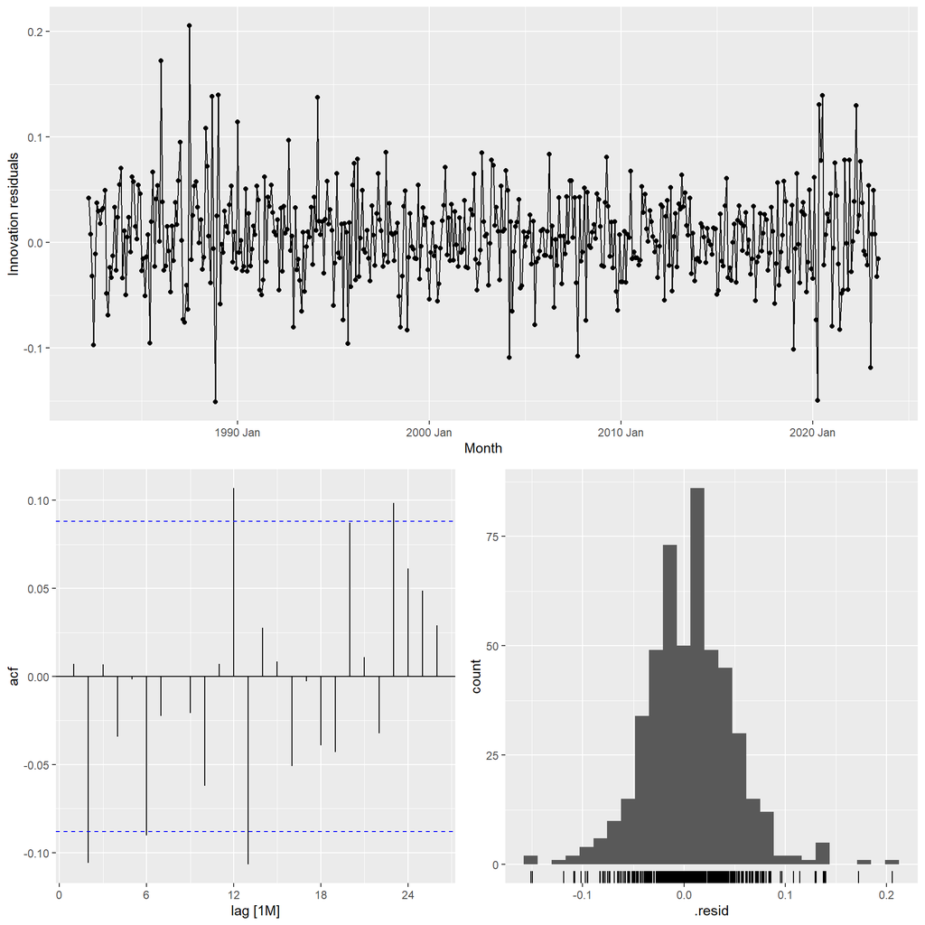

Figure 12: Residual diagnostics for the automatically selected ETS(M,Ad,M) model.

```r
auto_fit %>%
  gg_tsresiduals()
```

```r
ets_ljung_tbl <- bind_rows(
  fit %>%
    augment() %>%
    as_tibble() %>%
    transmute(Month, model = "Specified: ETS(M,A,M)", .innov),
  auto_fit %>%
    augment() %>%
    as_tibble() %>%
    transmute(Month, model = "R selected: ETS(M,Ad,M)", .innov)
) %>%
  as_tsibble(index = Month, key = model) %>%
  features(.innov, ljung_box, lag = 24, dof = 0)

ets_ljung_tbl %>%
  kable(digits = 3)
```

Table 7: Ljung-Box test comparison for ETS(M,A,M) and ETS(M,Ad,M).

| model | lb_stat | lb_pvalue |
| --- | --- | --- |
| R selected: ETS(M,Ad,M) | 39.409 | 0.025 |
| Specified: ETS(M,A,M) | 28.605 | 0.235 |

### Question 6

*Generate forecasts for the last two years of your sample using both alternative ETS models (you will need to re-estimate both models over the appropriate training sample). Plot the forecasts and forecast intervals. Briefly comment on these. Which model does best? (No more than 100 words). (8 marks)*

Figure 13 zooms in on the recent period so the last two-year forecasts are easier to compare. Both models capture seasonality but underestimate the sharp growth in the test period. ETS(M,Ad,M) is flatter because of damping. The intervals widen because residual uncertainty accumulates, and small residual outliers/spikes add uncertainty. Table 8 includes MASE; the lower test-set errors show ETS(M,A,M) performs better for this holdout period, although Q5 model selection is AICc-based.

```r
train_data <- my_series %>%
  slice(1:(n() - 24))

fit_train <- train_data %>%
  model(mam  = ETS(y ~ error("M") + trend("A")  + season("M")),
        madm = ETS(y ~ error("M") + trend("Ad") + season("M")))

fc_train <- fit_train %>%
  forecast(h = 24)
```

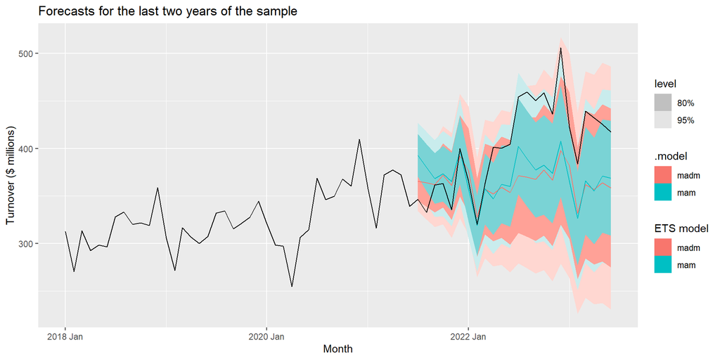

Figure 13: Zoomed forecasts for the last two years of the sample from ETS(M,A,M) and ETS(M,Ad,M).

```r
fc_train %>%
  autoplot(my_series %>% filter_index("2018 Jan" ~ .), level = c(80, 95)) +
  labs(
    title = "Forecasts for the last two years of the sample",
    x = "Month",
    y = "Turnover ($ millions)",
    colour = "ETS model"
  )
```

```r
acc_tbl <- fc_train %>%
  accuracy(my_series) %>%
  as_tibble() %>%
  mutate(model = recode(.model,
                        mam = "ETS(M,A,M)",
                        madm = "ETS(M,Ad,M)")) %>%
  select(model, RMSE, MAE, MAPE, MASE, RMSSE, ACF1)

acc_tbl %>%
  kable(digits = 3)
```

Table 8: Forecast accuracy over the last two years of the sample.

| model | RMSE | MAE | MAPE | MASE | RMSSE | ACF1 |
| --- | --- | --- | --- | --- | --- | --- |
| ETS(M,Ad,M) | 56.681 | 47.391 | 11.115 | 3.52 | 2.984 | 0.790 |
| ETS(M,A,M) | 52.924 | 45.505 | 10.833 | 3.38 | 2.786 | 0.788 |

### Question 7

*Generate forecasts for the two years following the end of your sample using your chosen model. Plot them and briefly comment on these. (No more than 100 words). (4 marks)*

As shown in Figure 14, the chosen ETS(M,Ad,M) model forecasts continuing seasonality with a damped upward movement. The intervals widen as the horizon increases because forecast uncertainty accumulates. This is also consistent with the residual diagnostics, where small outliers and autocorrelation spikes suggest remaining uncertainty around future peaks and troughs.

```r
chosen_fit <- my_series %>%
  model(madm = ETS(y ~ error("M") + trend("Ad") + season("M")))

future_fc <- chosen_fit %>%
  forecast(h = 24)
```

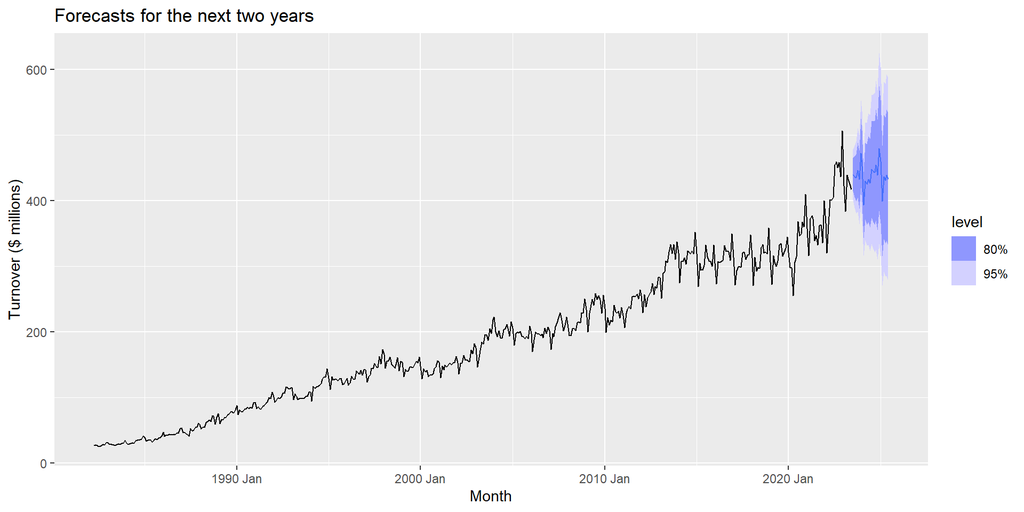

Figure 14: Forecasts for the next two years from the chosen ETS(M,Ad,M) model.

```r
future_fc %>%
  autoplot(my_series, level = c(80, 95)) +
  labs(
    title = "Forecasts for the next two years",
    x = "Month",
    y = "Turnover ($ millions)"
  )
```

## Project 3: ARIMA Modelling, Updating and Forecasting (IA4)

*Your aim in the first part of the assignment is to build an ARIMA model and use this to forecast. Recall the first step in ARIMA modelling is to stabilize the variance of your data. If you decided that your data required a transformation in the previous assignments you will be required to use the same transformation for what follows (unless you have a reason to change your mind - please do so if you think it is necessary).*

### Question 1

*Visually inspect your data and decide on the transformation and what differencing is required to achieve stationarity. Plot the data at every step and comment on each plot justifying your actions. (No more than 50 words per plot). (6 marks)*

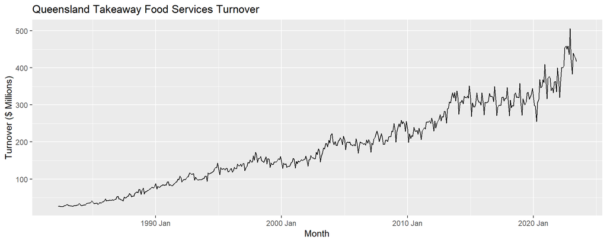

Figure 15: Original time plot for Queensland takeaway food services turnover.

```r
my_series %>%
  autoplot(y) +
  labs(title = "Queensland Takeaway Food Services Turnover",
       x = "Month", y = "Turnover ($ Millions)")
```

This series in Figure 15 shows monthly Queensland takeaway food services turnover in millions of dollars from April 1982 to June 2023. The series has a strong upward trend, monthly seasonality and increasing variation as the level rises. Since the data are monthly, $m = 12$, so seasonal differencing may be needed.

```r
lambda_tbl <- my_series %>%
  features(y, guerrero)

lambda <- lambda_tbl$lambda_guerrero

lambda_tbl %>%
  mutate(lambda_guerrero = round(lambda_guerrero, 4)) %>%
  rename(`Guerrero lambda` = lambda_guerrero) %>%
  kable(digits = 4)
```

Table 9: Guerrero lambda for the original series.

| Guerrero lambda |
| --- |
| 0.0595 |

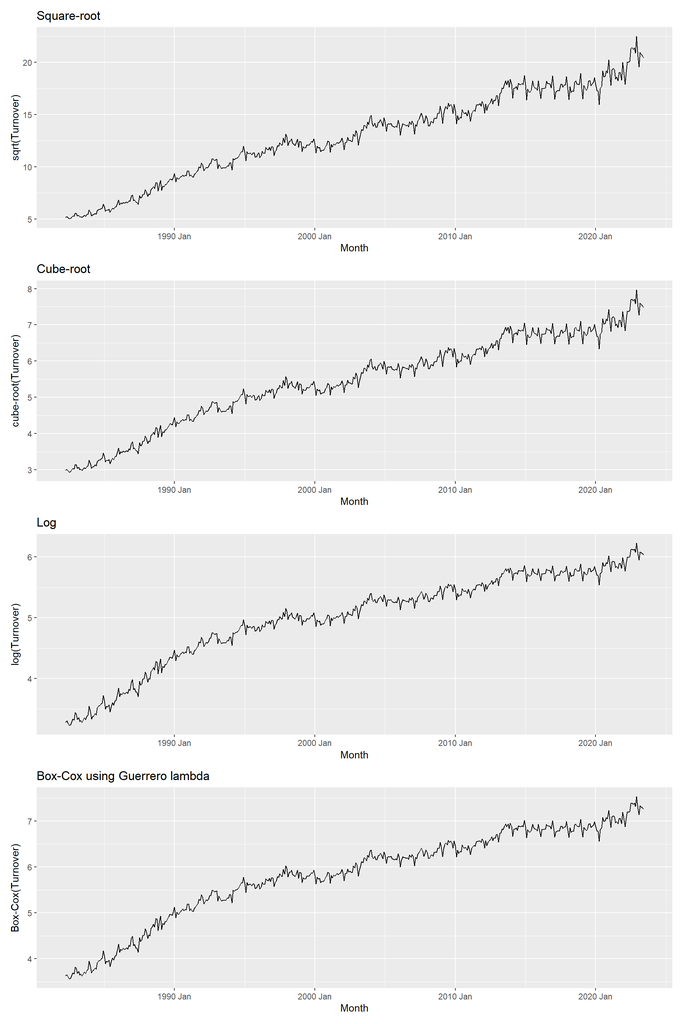

Figure 16: Comparison of transformations for Queensland takeaway food services turnover.

```r
p1 <- my_series %>%
  autoplot(sqrt(y)) +
  labs(title = "Square-root", x = "Month", y = "sqrt(Turnover)")

p2 <- my_series %>%
  autoplot(y^(1/3)) +
  labs(title = "Cube-root", x = "Month", y = "cube-root(Turnover)")

p3 <- my_series %>%
  autoplot(log(y)) +
  labs(title = "Log", x = "Month", y = "log(Turnover)")

p4 <- my_series %>%
  autoplot(box_cox(y, lambda)) +
  labs(title = "Box-Cox using Guerrero lambda", x = "Month", y = "Box-Cox(Turnover)")

p1 / p2 / p3 / p4
```

Figure 16 compares possible transformations. The original series shows increasing variation as the level rises. Square-root and cube-root transformations reduce the variance, but the plots still show increasing variation at higher levels. The log and Box-Cox transformations stabilise the spread best. Since Guerrero’s lambda is close to zero, I use `log(y)`.

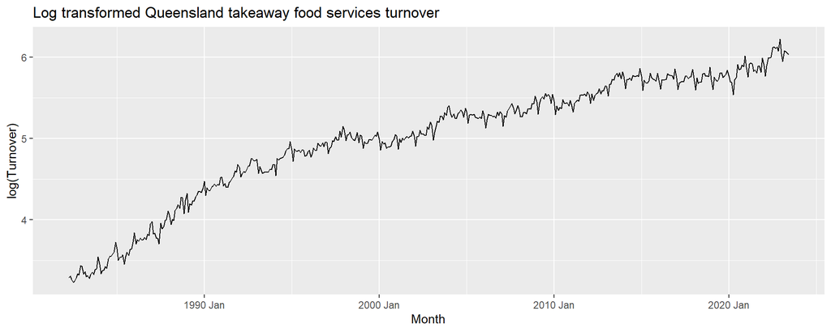

Figure 17: Log transformed turnover series.

```r
my_series %>%
  autoplot(log(y)) +
  labs(title = "Log transformed Queensland takeaway food services turnover",
       x = "Month", y = "log(Turnover)")
```

Figure 17 still shows trend and monthly seasonality after transformation, so differencing is needed. The log transformation is kept because the spread is more stable than the original scale.

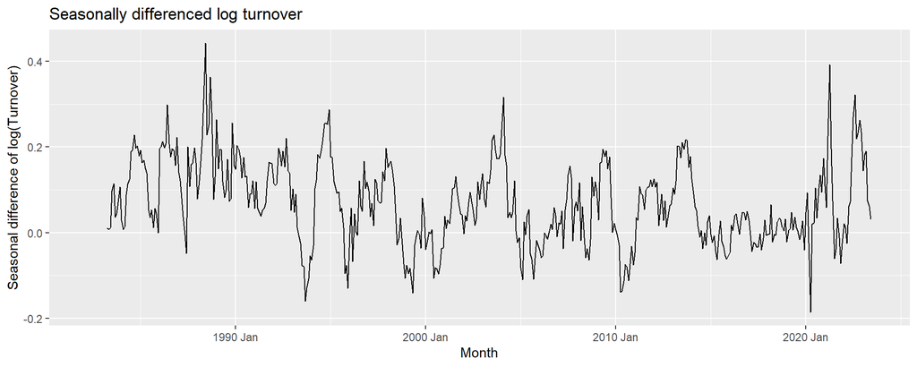

Figure 18: Seasonally differenced log turnover series.

```r
my_series %>%
  autoplot(difference(log(y), 12)) +
  labs(title = "Seasonally differenced log turnover",
       x = "Month", y = "Seasonal difference of log(Turnover)")
```

Figure 18 shows that seasonal differencing removes much of the yearly pattern, but the series still has slow movement over time. Therefore, a further first difference is needed.

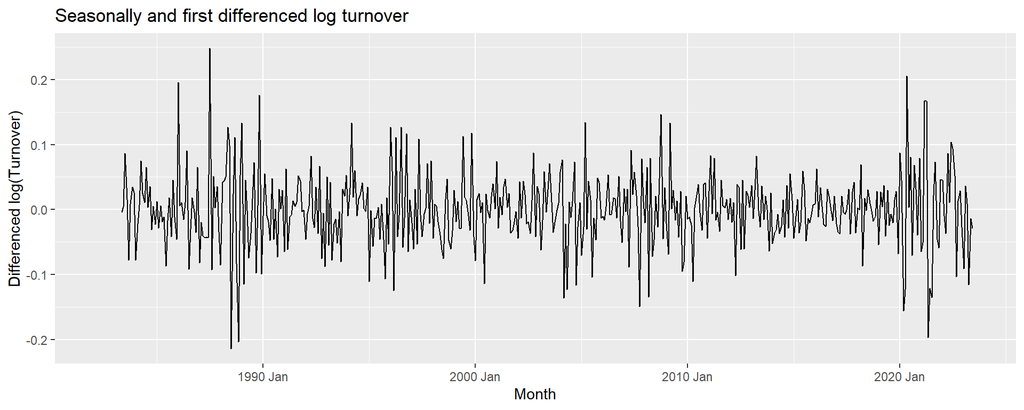

Figure 19: Seasonally and first differenced log turnover series.

```r
my_series %>%
  autoplot(difference(log(y), 12) %>% difference()) +
  labs(title = "Seasonally and first differenced log turnover",
       x = "Month", y = "Differenced log(Turnover)")
```

Figure 19 fluctuates around zero with a more stable spread and no obvious remaining trend. I therefore use `log(y)` with one seasonal difference and one first difference, so the ARIMA models below use $D = 1$, $d = 1$, and $m = 12$.

```r
seasonal_diff_tbl <- my_series %>%
  features(log(y), unitroot_nsdiffs)

first_diff_tbl <- my_series %>%
  features(difference(log(y), 12), unitroot_ndiffs)

bind_cols(seasonal_diff_tbl, first_diff_tbl) %>%
  kable()
```

Table 10: Unit root checks used as supporting evidence for differencing.

| nsdiffs | ndiffs |
| --- | --- |
| 1 | 1 |

Table 10 shows supporting unit root checks for the differencing decision. The test output suggests one seasonal difference and one ordinary difference, which agrees with my decision above.

### Question 2

*Plot the ACF and PACF of the stationary data. Reading from these choose an appropriate ARIMA model. Make sure you justify your choice. (No more than 70 words in total – do not revise the theory – describe what you see in your plots and decide what ARIMA orders may be appropriate. Also note that it is highly likely that the ACF and PACF plots will be very messy. Do the best you can). (6 marks)*

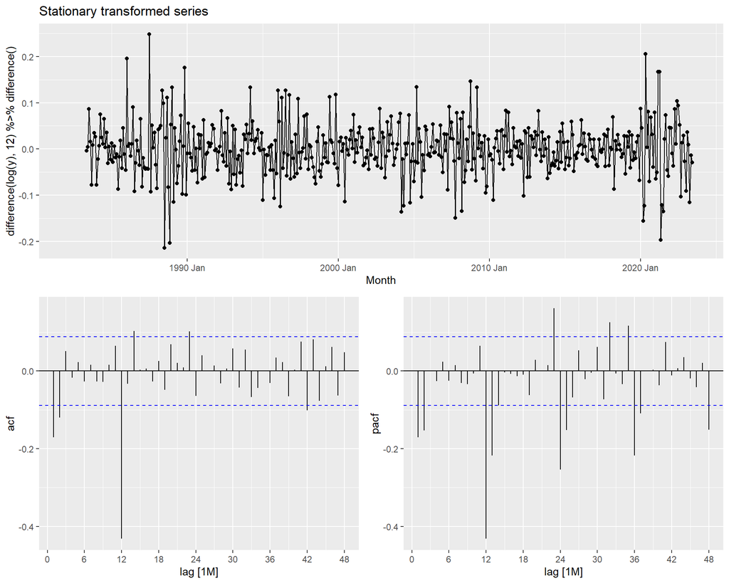

ACF and PACF of the stationary transformed series.

```r
my_series %>%
  gg_tsdisplay(difference(log(y), 12) %>% difference(),
               plot_type = "partial",
               lag_max = 48) +
  labs(title = "Stationary transformed series")
```

At non-seasonal lags, both ACF and PACF show early spikes up to about lag 2, suggesting possible MA(2) and AR(2). I use the PACF-based AR(2) as the initial choice because it is clearer. At seasonal lags, the ACF cuts off after lag 12, while the PACF gradually decays. I therefore choose seasonal MA(1), giving ARIMA(2,1,0)(0,1,1)$_{12}$.

### Question 3

*Check the whiteness of the residuals from the fitted ARIMA model. Based on these evaluate and if necessary review the ARIMA model specified in Q2. (No more than 50 words). (4 marks)*

```r
q3_fit <- my_series %>%
  model(q2_arima = ARIMA(log(y) ~ pdq(2, 1, 0) + PDQ(0, 1, 1)))

report(q3_fit)
```

```
Series: y
Model: ARIMA(2,1,0)(0,1,1)[12]
Transformation: log(y)

Coefficients:
          ar1      ar2     sma1
      -0.2734  -0.1608  -0.8529
s.e.   0.0450   0.0449   0.0272

sigma^2 estimated as 0.001857:  log likelihood=825.42
AIC=-1642.84   AICc=-1642.76   BIC=-1626.13
```

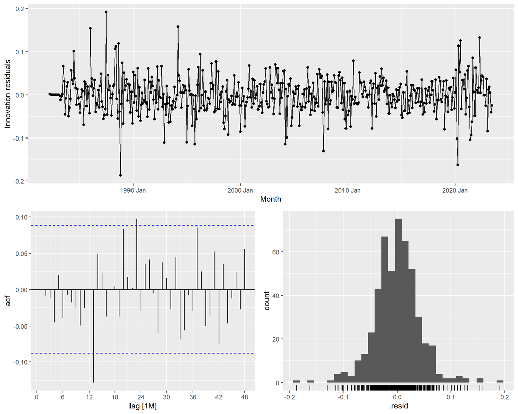

Figure 20: Residual diagnostics for the ARIMA(2,1,0)(0,1,1)[12] model.

```r
q3_fit %>%
  gg_tsresiduals(lag = 48)
```

```r
q3_fit %>%
  augment() %>%
  features(.innov, ljung_box, lag = 24, dof = 3) %>%
  kable(digits = 3)
```

Table 11: Ljung-Box test for ARIMA residual whiteness.

| .model | lb_stat | lb_pvalue |
| --- | --- | --- |
| q2_arima | 24.707 | 0.26 |

The residual plot shows no trend or seasonality, but two ACF spikes remain. I use Ljung–Box with lag 24 and dof 3, from two AR terms and one seasonal MA term. Since $p = 0.260 > 0.05$, I fail to reject $H_0: \rho_1 = \cdots = \rho_{24} = 0$ jointly at 5%; residuals are acceptable.

### Question 4

*Consider three (up to five if you think you need them) alternative ARIMA models based on your choice in Q2 and Q3. (Very briefly justify each choice with no more than 1 or 2 lines each). Use information criteria to choose the best model you have considered so far. (Very briefly justify each choice with no more than 1 or 2 lines each). (6 marks)*

```r
q4_fit <- my_series %>%
  model(arima210011 = ARIMA(log(y) ~ pdq(2,1,0) + PDQ(0,1,1)),
        arima012011 = ARIMA(log(y) ~ pdq(0,1,2) + PDQ(0,1,1)),
        arima210110 = ARIMA(log(y) ~ pdq(2,1,0) + PDQ(1,1,0)),
        arima012110 = ARIMA(log(y) ~ pdq(0,1,2) + PDQ(1,1,0)))
```

The following models are considered because the ACF and PACF in Q2 suggested two possible non-seasonal structures and two possible seasonal structures.

- `arima210011`: This is the initial model from Q2. It uses the PACF-based non-seasonal AR(2) and the clearer seasonal ACF cut-off after lag 12, suggesting seasonal MA(1).
- `arima012011`: This checks the ACF-based non-seasonal MA(2) alternative, while keeping the seasonal MA(1) term suggested by the seasonal ACF.
- `arima210110`: This keeps the PACF-based non-seasonal AR(2), but checks the seasonal PACF alternative by using seasonal AR(1) instead of seasonal MA(1).
- `arima012110`: This combines the ACF-based non-seasonal MA(2) alternative with the seasonal PACF-based AR(1) alternative.

```r
q4_fit %>%
  glance() %>%
  arrange(AICc) %>%
  select(.model, sigma2, log_lik, AIC, AICc, BIC) %>%
  mutate(across(where(is.numeric), ~ round(.x, 3))) %>%
  kable()
```

Table 12: Information criteria for manually selected ARIMA models.

| .model | sigma2 | log_lik | AIC | AICc | BIC |
| --- | --- | --- | --- | --- | --- |
| arima210011 | 0.002 | 825.421 | -1642.843 | -1642.759 | -1626.131 |
| arima012011 | 0.002 | 825.223 | -1642.446 | -1642.362 | -1625.734 |
| arima210110 | 0.002 | 762.064 | -1516.129 | -1516.045 | -1499.417 |
| arima012110 | 0.002 | 761.854 | -1515.709 | -1515.625 | -1498.997 |

Based on Table 12, `arima210011`, ARIMA(2,1,0)(0,1,1)$_{12}$, has the lowest AICc, so it is the best model considered so far. `arima012011` has a very similar AICc, so the ACF-based non-seasonal MA(2) alternative is also plausible. However, `arima210110` and `arima012110` have much higher AICc values. This suggests that the seasonal MA(1) structure is more appropriate than the seasonal AR(1) structure, so keeping (Q = 1) is important.

### Question 5

*Let the `ARIMA()` function choose a model. If you need to, make `ARIMA()` search harder exploring all possible options within the function. Perform a residual diagnostics analysis of the chosen model. How does this compare with your chosen model from Q4? (No more than 100 words). (6 marks)*

```r
q5_fit <- my_series %>%
  model(
    manual = ARIMA(log(y) ~ pdq(2,1,0) + PDQ(0,1,1)),
    auto = ARIMA(log(y),
                 stepwise = FALSE,
                 approximation = FALSE))
```

```r
q5_fit %>%
  select(auto) %>%
  report()
```

```
Series: y
Model: ARIMA(2,1,0)(0,1,1)[12]
Transformation: log(y)

Coefficients:
          ar1      ar2     sma1
      -0.2734  -0.1608  -0.8529
s.e.   0.0450   0.0449   0.0272

sigma^2 estimated as 0.001857:  log likelihood=825.42
AIC=-1642.84   AICc=-1642.76   BIC=-1626.13
```

```r
q5_fit %>%
  glance() %>%
  select(.model, sigma2, log_lik, AIC, AICc, BIC) %>%
  mutate(across(where(is.numeric), ~ round(.x, 3))) %>%
  kable()
```

Table 13: Information criteria comparison between the manual and automatic ARIMA models.

| .model | sigma2 | log_lik | AIC | AICc | BIC |
| --- | --- | --- | --- | --- | --- |
| manual | 0.002 | 825.421 | -1642.843 | -1642.759 | -1626.131 |
| auto | 0.002 | 825.421 | -1642.843 | -1642.759 | -1626.131 |

```r
q5_fit %>%
  tidy() %>%
  select(.model, term, estimate, std.error) %>%
  mutate(across(where(is.numeric), ~ round(.x, 4))) %>%
  kable()
```

Table 14: Parameter comparison between the manual and automatic ARIMA models.

| .model | term | estimate | std.error |
| --- | --- | --- | --- |
| manual | ar1 | -0.2734 | 0.0450 |
| manual | ar2 | -0.1608 | 0.0449 |
| manual | sma1 | -0.8529 | 0.0272 |
| auto | ar1 | -0.2734 | 0.0450 |
| auto | ar2 | -0.1608 | 0.0449 |
| auto | sma1 | -0.8529 | 0.0272 |

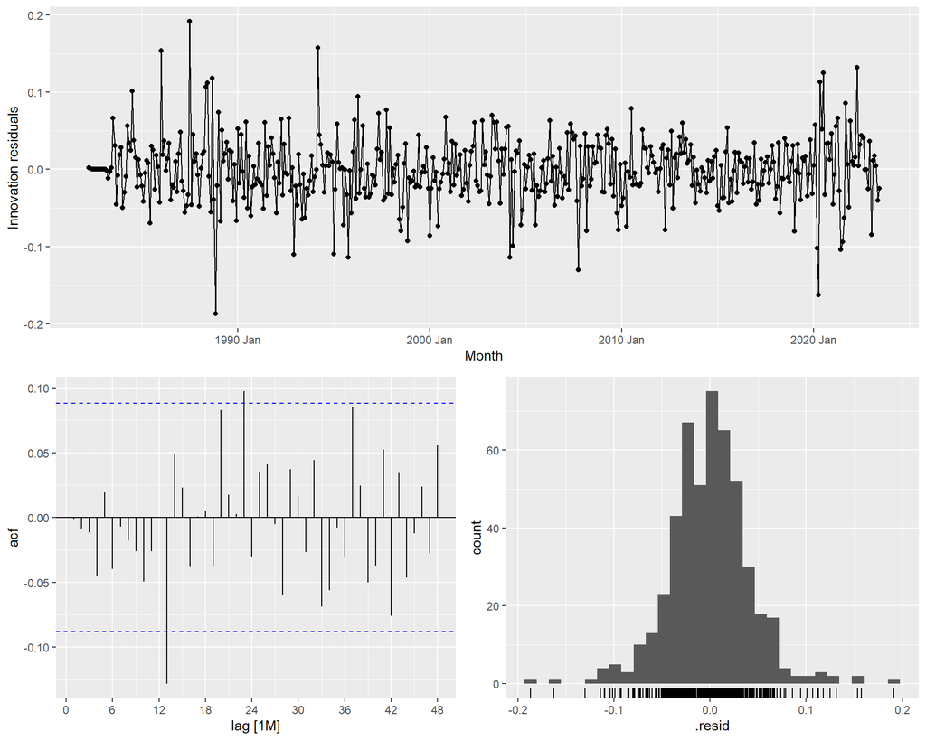

Figure 21: Residual diagnostics for the automatically selected ARIMA model.

```r
q5_fit %>%
  select(auto) %>%
  gg_tsresiduals(lag = 48)
```

```r
q5_fit %>%
  select(auto) %>%
  augment() %>%
  features(.innov, ljung_box, lag = 24, dof = 3) %>%
  kable(digits = 3)
```

Table 15: Ljung-Box test for residual whiteness of the automatically selected ARIMA model.

| .model | lb_stat | lb_pvalue |
| --- | --- | --- |
| auto | 24.707 | 0.26 |

The full search with `stepwise = FALSE` and `approximation = FALSE` selected the same ARIMA(2,1,0)(0,1,1)$_{12}$ model as my manual choice. Since there is no separate automatic model to compare, I confirm equivalence using orders, estimates in Table 14, AICc in Table 13, and diagnostics in Figure 21 and Table 15. This supports Q4. Residuals show no trend or seasonality, but two ACF spikes remain. Using lag 24 and dof 3 from two AR terms and one seasonal MA term, I test $H_0: \rho_1 = \cdots = \rho_{24} = 0$ jointly. Since $p = 0.260 > 0.05$, I fail to reject $H_0$ at 5%.

**This identical-model situation was discussed with teaching staff on the discussion forum. Please see Ed post #201.**

### Question 6

*Remember that you cannot use information criteria to compare between models with different orders of differencing.* **If necessary** *use an appropriate test set to choose the ARIMA model you want to use for forecasting. Which model have you selected and why? (No more than 50 words). (4 marks)*

Since I am not comparing ARIMA models with different differencing orders, a test set is not needed here. All considered models use `log(y)`, $d = 1$ and $D = 1$. I therefore select ARIMA(2,1,0)(0,1,1)$_{12}$ because it has the lowest AICc, acceptable residual diagnostics, and matches the automatic ARIMA result.

**This approach was confirmed with teaching staff on the discussion forum. Please see Ed post #201.**

### Question 7

*Generate and plot forecasts and forecast intervals from your chosen ARIMA model for two years following the end of your sample. Comment on these. (No more than 50 words). (3 marks)*

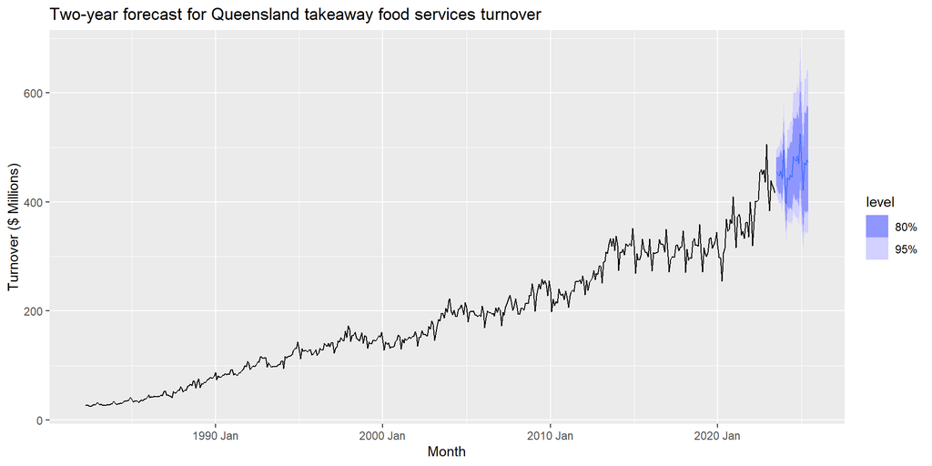

Figure 22: Two-year forecasts from the selected ARIMA(2,1,0)(0,1,1)[12] model.

```r
q7_fc <- q5_fit %>%
  select(auto) %>%
  forecast(h = "2 years")

q7_fc %>%
  autoplot(my_series, level = c(80, 95)) +
  labs(title = "Two-year forecast for Queensland takeaway food services turnover",
       x = "Month", y = "Turnover ($ Millions)")
```

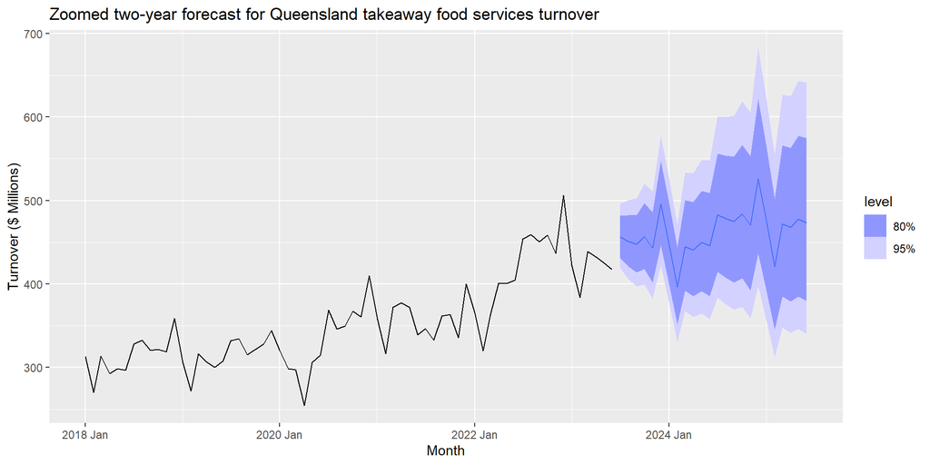

Figure 23: Zoomed two-year forecasts from the selected ARIMA(2,1,0)(0,1,1)[12] model.

```r
q7_fc %>%
  autoplot(my_series %>% filter(year(Month) >= 2018),
           level = c(80, 95)) +
  labs(title = "Zoomed two-year forecast for Queensland takeaway food services turnover",
       x = "Month",
       y = "Turnover ($ Millions)")
```

The forecasts continue the recent upward movement and retain monthly seasonal variation. The model captures the strong increase after 2020 and extends this higher level into the forecast period. The prediction intervals widen because uncertainty accumulates in the differenced ARIMA model, and two residual ACF spikes suggest some remaining uncertainty.

### Question 8

*You have now considered several modelling frameworks and built several models for your data set. In this part of the assignment you will evaluate these.*

*Update your data from the ABS website [https://www.abs.gov.au/statistics/industry/retail-and-wholesale-trade/retail-trade-australia](https://www.abs.gov.au/statistics/industry/retail-and-wholesale-trade/retail-trade-australia%20Table%2011). Explore your updated time series and comment on the series movement through and post the COVID-19 pandemic. Provide any necessary plots to support your analysis. Some States and Industries are unfortunately affected more than others. (6 marks)*

```r
updated_series <- read_excel(
  "8501011.xlsx", sheet = "Data1", skip = 9) %>%
  select(Month = 1, y = A3349718A) %>%
  mutate(Month = yearmonth(as.Date(Month)),
         y = as.numeric(y)) %>%
  as_tsibble(index = Month)
```

```r
monthly_counts <- updated_series %>%
  as_tibble() %>%
  count(Month)

updated_summary <- monthly_counts %>%
  summarise(
    `Start month` = min(Month),
    `End month` = max(Month),
    `One observation for each month` =
      if_else(sum(n) == ((year(max(Month)) - year(min(Month))) * 12 +
             (month(max(Month)) - month(min(Month))) + 1) &
          min(n) == 1 & max(n) == 1,
        "Yes", "No"))

updated_summary %>%
  kable()
```

Table 16: Coverage check for the updated Queensland takeaway food services turnover series.

| Start month | End month | One observation for each month |
| --- | --- | --- |
| 1982 Apr | 2025 Jun | Yes |

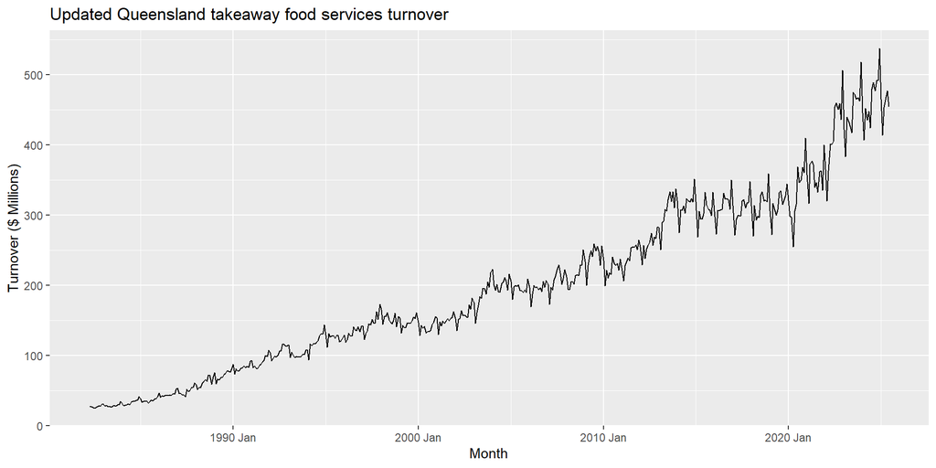

Figure 24: Updated Queensland takeaway food services turnover series.

```r
updated_series %>%
  autoplot(y) +
  labs(title = "Updated Queensland takeaway food services turnover",
       x = "Month", y = "Turnover ($ Millions)")
```

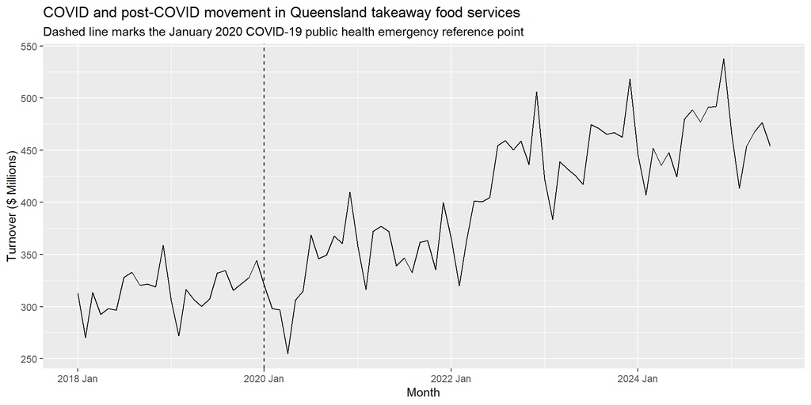

Figure 25: Queensland takeaway food services turnover from 2018 onward.

```r
updated_series %>%
  filter(year(Month) >= 2018) %>%
  autoplot(y) +
  geom_vline(xintercept = yearmonth("2020 Jan"),
             linetype = "dashed") +
  labs(
    title = "COVID and post-COVID movement in Queensland takeaway food services",
    subtitle = "Dashed line marks the January 2020 COVID-19 public health emergency reference point",
    x = "Month",
    y = "Turnover ($ Millions)")
```

Table 16 shows that the updated series runs from April 1982 to June 2025, with one observation for each month. Figure 24 shows that the updated data continue the long-run upward trend. Figure 25 focuses on the COVID and post-COVID period. I use January 2020 as a reference point because Queensland declared a public health emergency for COVID-19 on 29 January 2020 (The State of Queensland, 2020).

Turnover fell sharply around April 2020, but the effect appears mainly limited to that month. It recovered soon after and quickly returned to its previous level. During 2021, the series stayed relatively stable and above the pre-COVID level. From 2022 onwards, turnover increased more strongly and continued moving upward. Overall, Queensland takeaway food services appear to have been briefly disrupted by COVID, then recovered and continued growing in the post-COVID period.

### Question 9

*Generate forecasts for the period post 2022 until the end of your sample, from the models considered “best” in all assignments. More specifically, generate forecasts from the best benchmark, the best ETS and best ARIMA model. Plot the forecasts (both point forecasts and prediction intervals) together with the observed data and comment on these. (Make sure you can clearly visualise these. You may choose to plot on multiple graphs.) (6 marks)*

```r
q9_train <- updated_series %>%
  filter_index(. ~ "2022 Dec")

q9_test <- updated_series %>%
  filter_index("2023 Jan" ~ .)

q9_fit <- q9_train %>%
  model(benchmark = RW(log(y) ~ drift()),
        ets = ETS(y ~ error("M") + trend("A") + season("M")),
        arima = ARIMA(log(y) ~ pdq(2,1,0) + PDQ(0,1,1)))

q9_fc <- q9_fit %>%
  forecast(h = nrow(q9_test))
```

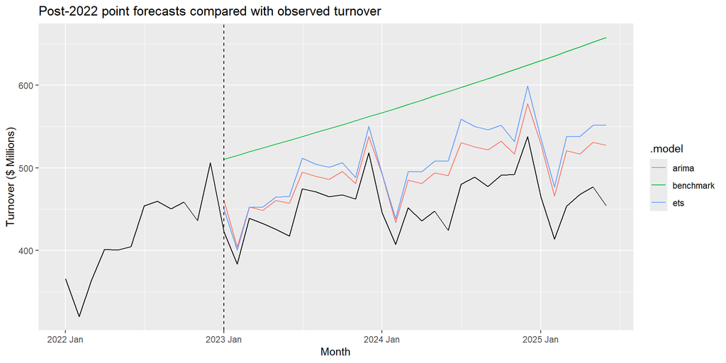

Figure 26: Post-2022 point forecasts from the best benchmark, ETS and ARIMA models.

```r
q9_fc %>%
  autoplot(updated_series %>% filter(year(Month) >= 2022),
           level = NULL) +
  geom_vline(xintercept = yearmonth("2023 Jan"),
             linetype = "dashed") +
  labs(title = "Post-2022 point forecasts compared with observed turnover",
       x = "Month",
       y = "Turnover ($ Millions)")
```

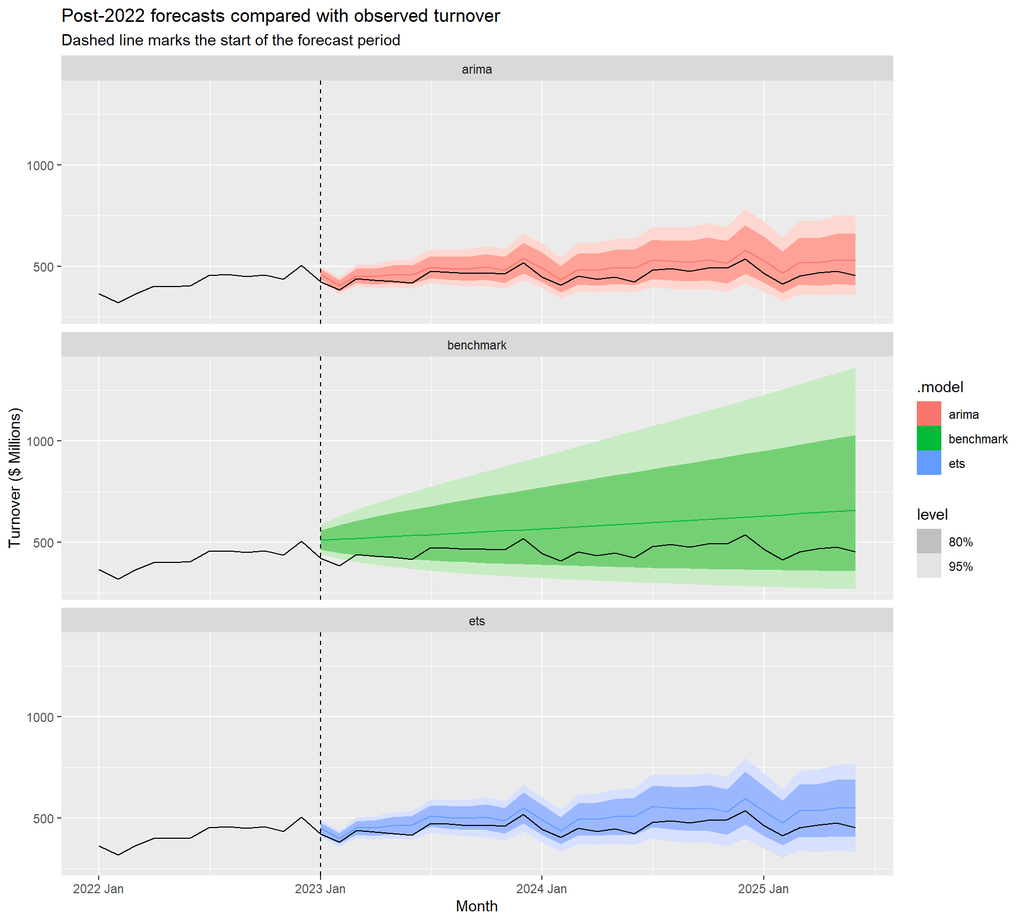

Figure 27: Post-2022 forecasts and prediction intervals from the best benchmark, ETS and ARIMA models.

```r
q9_fc %>%
  autoplot(updated_series %>% filter(year(Month) >= 2022),
           level = c(80, 95)) +
  geom_vline(xintercept = yearmonth("2023 Jan"),
             linetype = "dashed") +
  facet_wrap(~ .model, ncol = 1) +
  labs(title = "Post-2022 forecasts compared with observed turnover",
       subtitle = "Dashed line marks the start of the forecast period",
       x = "Month",
       y = "Turnover ($ Millions)")
```

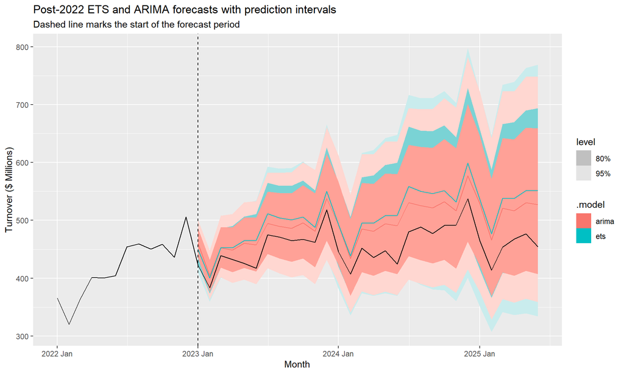

Figure 28: Post-2022 ETS and ARIMA forecasts with prediction intervals.

```r
q9_fc %>%
  filter(.model %in% c("ets", "arima")) %>%
  autoplot(updated_series %>% filter(year(Month) >= 2022),
           level = c(80, 95)) +
  geom_vline(xintercept = yearmonth("2023 Jan"),
             linetype = "dashed") +
  labs(title = "Post-2022 ETS and ARIMA forecasts with prediction intervals",
       subtitle = "Dashed line marks the start of the forecast period",
       x = "Month",
       y = "Turnover ($ Millions)")
```

The models are fitted using data up to December 2022 and forecast from January 2023 to June 2025. Figure 26 overlays the point forecasts from the three models, making direct comparison easier. All three models tend to overestimate turnover in parts of the post-2022 period. The benchmark drift model is clearly the weakest because it continues the upward trend but does not capture monthly seasonality. In contrast, ETS and ARIMA capture the seasonal pattern much better.

Visually, ARIMA appears closer to the observed turnover over more of the post-2022 period, especially later in the forecast horizon. Both ETS and ARIMA still miss some sharper observed drops, such as the late-year drop around November, where actual turnover falls more strongly than the forecasts. ETS appears slightly closer at the very beginning of the forecast period, particularly around January and February 2023, where ARIMA is above the observed values.

Figure 27 shows the forecasts and prediction intervals for all three models. The benchmark has much wider intervals, reflecting greater forecast uncertainty. ETS and ARIMA show more similar seasonal forecast patterns. Figure 28 compares their intervals more directly. ETS has narrower intervals before around January 2024, but its intervals become wider than ARIMA’s later in the forecast period. The January 2023 observation falls outside ARIMA’s interval but is captured by ETS’s 80% interval, suggesting ETS better captures uncertainty for that specific early observation. The first-year supporting check and the overall point forecast accuracy are evaluated quantitatively in Question 10.

### Question 10

*Evaluate the accuracy of the point forecasts over the period post 2022. A table with accuracy measures will be necessary to be presented here. Comment on which forecasts are the most accurate. (4 marks)*

```r
q10_accuracy <- q9_fc %>%
  accuracy(updated_series) %>%
  select(.model, ME, RMSE, MAE, MAPE, MASE, RMSSE) %>%
  arrange(RMSE)

q10_accuracy %>%
  mutate(across(where(is.numeric), ~ round(.x, 3))) %>%
  kable()
```

Table 17: Post-2022 point forecast accuracy for the best benchmark, ETS and ARIMA models.

| .model | ME | RMSE | MAE | MAPE | MASE | RMSSE |
| --- | --- | --- | --- | --- | --- | --- |
| arima | -38.417 | 41.778 | 38.417 | 8.465 | 2.607 | 1.867 |
| ets | -50.863 | 55.293 | 50.863 | 11.115 | 3.452 | 2.471 |
| benchmark | -124.857 | 131.983 | 124.857 | 27.729 | 8.473 | 5.898 |

```r
q9_accuracy_2023 <- q9_fc %>%
  filter_index("2023 Jan" ~ "2023 Dec") %>%
  accuracy(updated_series %>% filter_index("2023 Jan" ~ "2023 Dec")) %>%
  select(.model, ME, RMSE, MAE, MAPE) %>%
  arrange(RMSE)

q9_accuracy_2023 %>%
  mutate(across(where(is.numeric), ~ round(.x, 3))) %>%
  kable()
```

Table 18: Point forecast accuracy for the first forecast year, 2023.

| .model | ME | RMSE | MAE | MAPE |
| --- | --- | --- | --- | --- |
| arima | -24.161 | 25.647 | 24.161 | 5.471 |
| ets | -30.701 | 32.240 | 30.701 | 6.841 |
| benchmark | -87.625 | 90.389 | 87.625 | 20.006 |

Table 17 shows that ARIMA has the lowest RMSE, MAE, MAPE, MASE and RMSSE, so it gives the most accurate point forecasts over the full post-2022 period. ETS is the second-best model, while the benchmark drift model performs worst. The supporting first-year check in Table 18 gives the same ranking using ME, RMSE, MAE and MAPE. I do not report MASE and RMSSE in the 2023-only supporting table because this table is only a short-horizon check. When only the one-year test period is supplied to `accuracy()`, these scaled measures can return `NaN`, so I use ME, RMSE, MAE and MAPE for this supplementary comparison.

The negative ME values in both tables show that all three models overestimate turnover on average. This is especially large for the benchmark model, which supports the visual pattern in Figure 26 and Figure 27. The benchmark also performs poorly because it does not capture the monthly seasonal pattern.

### Question 11

*Use all three models to forecast the next 24-months of your updated series. Generate the necessary plots and comment on the forecasts. Make sure you can clearly visualise these. How have your models faired amidst the effects of COVID-19? (9 marks)*

```r
q11_fit <- updated_series %>%
  model(benchmark = RW(log(y) ~ drift()),
        ets = ETS(y ~ error("M") + trend("A") + season("M")),
        arima = ARIMA(log(y) ~ pdq(2,1,0) + PDQ(0,1,1)))

q11_fc <- q11_fit %>%
  forecast(h = "24 months")
```

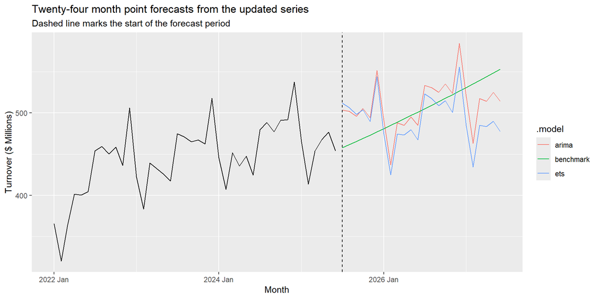

Figure 29: Twenty-four month point forecasts from the best benchmark, ETS and ARIMA models.

```r
q11_fc %>%
  autoplot(updated_series %>% filter(year(Month) >= 2022),
           level = NULL) +
  geom_vline(xintercept = yearmonth("2025 Jul"),
             linetype = "dashed") +
  labs(title = "Twenty-four month point forecasts from the updated series",
       subtitle = "Dashed line marks the start of the forecast period",
       x = "Month",
       y = "Turnover ($ Millions)")
```

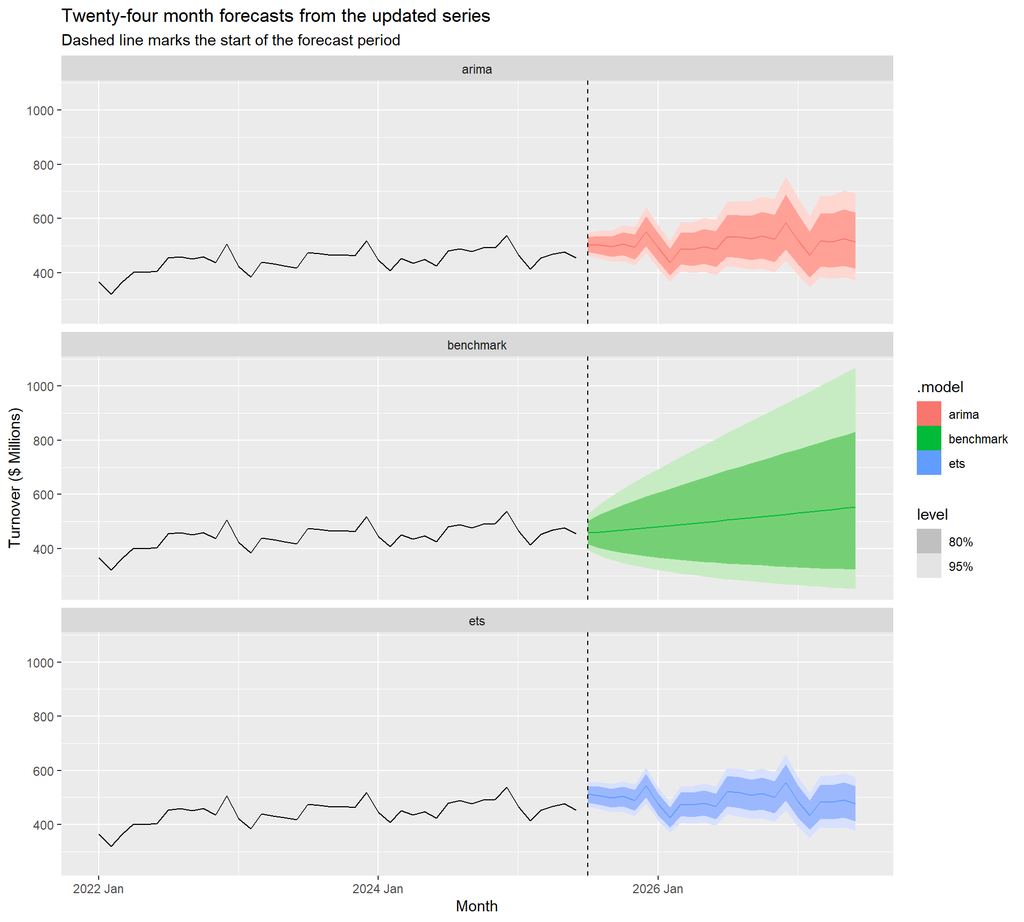

Figure 30: Twenty-four month forecasts from the best benchmark, ETS and ARIMA models fitted to the updated series.

```r
q11_fc %>%
  autoplot(updated_series %>% filter(year(Month) >= 2022),
           level = c(80, 95)) +
  geom_vline(xintercept = yearmonth("2025 Jul"),
             linetype = "dashed") +
  facet_wrap(~ .model, ncol = 1) +
  labs(title = "Twenty-four month forecasts from the updated series",
       subtitle = "Dashed line marks the start of the forecast period",
       x = "Month",
       y = "Turnover ($ Millions)")
```

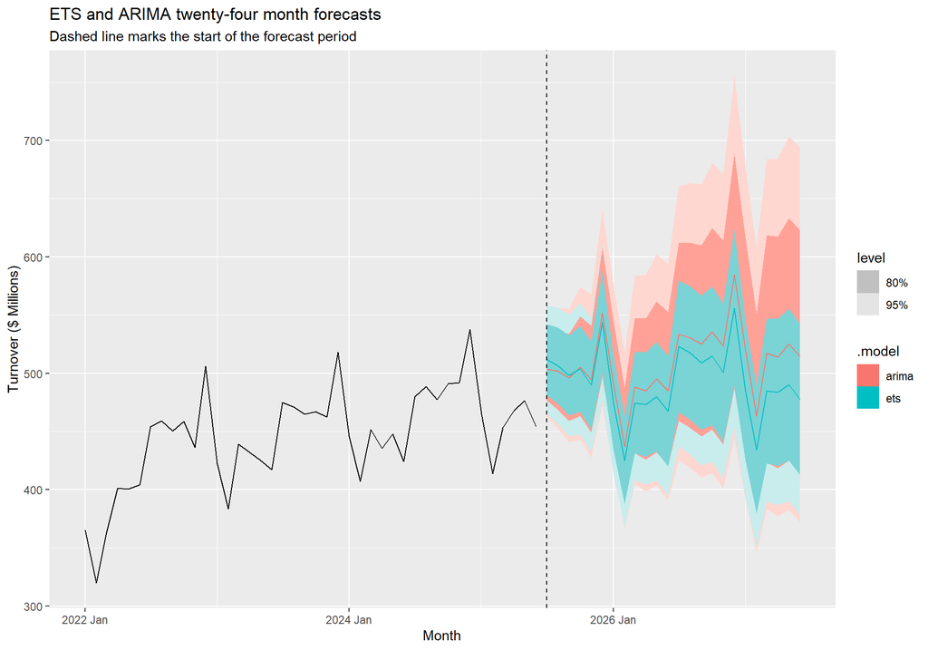

Figure 31: Twenty-four month forecasts from the ETS and ARIMA models fitted to the updated series.

```r
q11_fc %>%
  filter(.model %in% c("ets", "arima")) %>%
  autoplot(updated_series %>% filter(year(Month) >= 2022),
           level = c(80, 95)) +
  geom_vline(xintercept = yearmonth("2025 Jul"),
             linetype = "dashed") +
  labs(title = "ETS and ARIMA twenty-four month forecasts",
       subtitle = "Dashed line marks the start of the forecast period",
       x = "Month",
       y = "Turnover ($ Millions)")
```

Figure 29 overlays the 24-month point forecasts after refitting all three models to the full updated series. The benchmark drift model continues the upward movement but does not capture monthly seasonality. ETS and ARIMA both retain the seasonal movements and forecast turnover at the higher post-COVID level.

Figure 30 shows the corresponding prediction intervals for all three models. The benchmark has much wider intervals, reflecting accumulated uncertainty from a random walk with drift. Since the benchmark is clearly different and less useful for seasonal movement, I then compare ETS and ARIMA together in Figure 31 as a focused comparison of the two seasonal models.

In Figure 31, ETS and ARIMA have similar seasonal forecast patterns, but their uncertainty differs. ARIMA has much wider prediction intervals, especially as the forecast horizon increases, suggesting greater model-implied uncertainty. ETS gives tighter intervals, while ARIMA had the best first-year and overall post-2022 point forecast accuracy in Table 18 and Table 17. This suggests that ARIMA fared best for point forecasting, although its future forecasts are more uncertain than ETS.

The COVID disruption appears brief in Figure 25, so the models adapt reasonably well after being refitted to the updated data. However, Table 17 showed that all three models overestimated the post-2022 period on average, so the future forecasts should still be interpreted cautiously. None of the models explicitly includes a COVID intervention effect; they only learn from the updated post-COVID pattern.

### Reference

Australian Bureau of Statistics. (2025, July 31). *Retail Trade, Australia, June 2025*. https://www.abs.gov.au/statistics/industry/retail-and-wholesale-trade/retail-trade-australia/jun-2025

The State of Queensland. (2020, March 16). *Queensland first to make emergency declarations in January*. Ministerial Media Statements. https://statements.qld.gov.au/statements/89540

### AI Declaration

I used ChatGPT for grammar correction, rephrasing, and improving the clarity of my explanations. All code, model choices, interpretations, and final edits were reviewed and decided by me.